# Final filtering for downstream analyses for sc-/sn-RNA-Seq Analysis in 10X Genomics data

Antonia Chroni for SJCRH DNB_BINF_Core

[figure not shown]

**PI: PI_NAME**  
**Project: Victoria_Knockout - Legacy LSF launch_full_pipeline.sh script**  
Task: KIDS26 Hackathon Demo Cohort  
Project Lead(s): NA  
Department: Developmental Neurobiology

DNB Bioinformatics Core Analysis Team:

> **Lead Analyst(s): Antonia Chroni, PhD**  
> Group Lead: Cody A. Ramirez, PhD  
> **Contact E-mail:** user@example.org  
> **DNB Bioinformatics Core Pipeline:** Standard sc-/sn-RNA-Seq Analysis in 10X Genomics data

Reviewed by: _____________________ Date: ____________

# 1 Information about this notebook

This notebook combines the following matrices to filter out any low-quality cells and contamination. 1. `seurat_obj.rds` as generated by the Seurat workflow and miQC R package, 2. `SoupX_corrected_mtx_merged.rds` as generated by the SoupX method, and 3. `merged_seurat_obj_with_doublets.rds` as generated by the scDblFinder method.

# 2 Set up

```r
suppressPackageStartupMessages({
  library(devtools)
  library(future)
  library(Seurat)
  library(patchwork)
  library(tidyverse)
  library(ggthemes)
  library(scooter)
  library(RColorBrewer)
  library(knitr)

  # Evaluate Seurat R expressions asynchronously when possible using future package
  options(future.globals.maxSize = future_globals_value)
  plan(multisession, workers = parallelly::availableCores())})
```

# 3 Directories and paths to file Inputs/Outputs

```r
attach(params)
```

```r
analysis_dir <- file.path(root_dir, "analyses", "upstream-analysis")
module_results_dir <- file.path(analysis_dir, "results")
seurat_results_dir <- file.path(analysis_dir, "results", "02_Seurat_qc")
#SoupX_results_dir <- file.path(analysis_dir, "results", "01_SoupX")
scDblFinder_results_dir <- file.path(analysis_dir, "results", "03_scDblFinder")
module_plots_dir <- file.path(analysis_dir, "plots")

# Input files
seurat_results_file <- c(dir(path = seurat_results_dir,  pattern = "seurat_obj.rds", full.names = TRUE, recursive = TRUE))
#SoupX_file <- file.path(SoupX_results_dir, "SoupX_corrected_mtx_merged.rds")
scDblFinder_file <- file.path(scDblFinder_results_dir, "merged_seurat_obj_with_doublets.rds")
project_metadata_file <- file.path(metadata_dir, metadata_file) # metadata input file
gradient_palette_file <- file.path(root_dir, "figures", "palettes", "gradient_color_palette.tsv")

# Create results_dir
results_dir <- file.path(module_results_dir, "04_Filter_object")
if (!dir.exists(results_dir)) {
  dir.create(results_dir)}

# Create plots directory
plots_dir <- file.path(module_plots_dir, "04_Filter_object")
if (!dir.exists(plots_dir)) {
  dir.create(plots_dir)}

source(paste0(root_dir, "/figures/scripts/theme_plot.R"))
source(paste0(analysis_dir, "/util/function-process-Seurat.R"))
source(paste0(analysis_dir, "/util/function-create-UMAP.R"))
```

# 4 Read metadata file and define `sample_name`

```r
# Read metadata
project.metadata <- read.csv(project_metadata_file, sep = '\t', header = TRUE)
sample_name <- unique(as.character(project.metadata$ID))
sample_name <- sort(sample_name, decreasing = FALSE)
print(sample_name)
```

```
## [1] "DYE_2519" "DYE_2520" "DYE_2521" "DYE_2522"
```

```r
# Read color palette
gradient_palette_df <- readr::read_tsv(gradient_palette_file, guess_max = 100000, show_col_types = FALSE)
```

# 5 Read and merge `seurat_qc` object

First, we will merge the `seurat_obj.rds` objects from all samples in the project as generated by the `seurat_qc` pipeline.

```r
# Create list
seurat_obj_list <- list()

for (i in seq_along(sample_name)) {
  # Check if the file exists
  if (file.exists(seurat_results_file[i])) {
    cat("Reading in data for sample:", sample_name[i], "\n")
    seurat_obj_list[i] <- readRDS(seurat_results_file[i])
  } else {
    cat("File does not exist for sample:", sample_name[i], "\n")
  }
}
```

```
## Reading in data for sample: DYE_2519
## Reading in data for sample: DYE_2520
## Reading in data for sample: DYE_2521
## Reading in data for sample: DYE_2522
```

```r
# Print the list of Seurat objects
print(seurat_obj_list)
```

```
## [[1]]
## An object of class Seurat
## 21763 features across 3464 samples within 1 assay
## Active assay: RNA (21763 features, 3000 variable features)
##  3 layers present: counts, data, scale.data
##  2 dimensional reductions calculated: pca, umapndim30nn30
##
## [[2]]
## An object of class Seurat
## 22039 features across 5432 samples within 1 assay
## Active assay: RNA (22039 features, 3000 variable features)
##  3 layers present: counts, data, scale.data
##  2 dimensional reductions calculated: pca, umapndim30nn30
##
## [[3]]
## An object of class Seurat
## 20190 features across 5278 samples within 1 assay
## Active assay: RNA (20190 features, 3000 variable features)
##  3 layers present: counts, data, scale.data
##  2 dimensional reductions calculated: pca, umapndim30nn30
##
## [[4]]
## An object of class Seurat
## 21412 features across 7049 samples within 1 assay
## Active assay: RNA (21412 features, 3000 variable features)
##  3 layers present: counts, data, scale.data
##  2 dimensional reductions calculated: pca, umapndim30nn30
```

```r
# Merge all seurat objects in the list into one
# The first parameter of merge should be a Seurat object, the second (y) can be one Seurat object or a list of several.
seurat_obj <- merge(x = seurat_obj_list[[1]], y = seurat_obj_list[-1],
                    project = PROJECT_NAME)
print(DefaultAssay(seurat_obj) <- "RNA") # Switch the default to RNA
```

```
## [1] "RNA"
```

```r
saveRDS(seurat_obj, file = paste0(results_dir, "/", "seurat_obj_merged.rds")) # Save merged object
#############################################################################
# Estimate `cells_number_seurat_qc` per sample_name
cells_number_seurat_qc <- table(seurat_obj@meta.data$orig.ident) %>%
    as.data.frame() %>%
    mutate(sample_name = Var1,
           cells_number_seurat_qc = Freq) %>%
    dplyr::select(-Var1, -Freq)
```

# 6 Filter ambient RNA

Next, we will use the corrected matrices from all samples as generated by [SoupX](https://cran.r-project.org/web/packages/SoupX/vignettes/pbmcTutorial.html). This is an optional step, so it will be skipped or not as defined in `params`.

```r
# Indicates whether or not to use the SoupX corrected matrix for filtering or to skip it
if (use_SoupX_filtering == "YES"){
  print_message <- "we will use SoupX corrected matrix"
  #SoupX_seurat_obj <- readRDS(SoupX_file) # Read SoupX_seurat_obj
  #colnames(seurat_obj)[which(!(colnames(seurat_obj) %in% colnames(SoupX_seurat_obj) ))]
  #seurat_obj <- subset(seurat_obj, cells=colnames(seurat_obj)[which(!(colnames(seurat_obj) %in% colnames(SoupX_seurat_obj) ))], invert=TRUE)
  #SoupX_seurat_obj <- SoupX_seurat_obj[,colnames(seurat_obj)]
  #seurat_obj[["RNA_SoupX"]] <- CreateAssayObject(counts = seurat_obj[["RNA"]])
  counts <- GetAssayData(object = seurat_obj, assay  = "RNA", slot   = "counts")
  seurat_obj[["RNA_SoupX"]] <- CreateAssayObject(counts = counts)
  #seurat_obj <- RenameAssays(seurat_obj, RNA = "RNA_SoupX")
  DefaultAssay(seurat_obj) <- "RNA_SoupX"

  cat("Cells_number_after_filter_ambient_RNA per orig.ident", "\n")
  print(table(seurat_obj@meta.data$orig.ident))
  cat("Cells_number_after_filter_ambient_RNA per ID", "\n")
  print(table(seurat_obj@meta.data$ID))
  } else {
    print_message <- "we will skip usage of the SoupX corrected matrix"}
```

Here, we will skip usage of the SoupX corrected matrix.

# 7 Filter doublets out

Next, we will remove any doublets from all samples as identified by [ScDblFinder](https://bioconductor.org/packages/devel/bioc/vignettes/scDblFinder/inst/doc/scDblFinder.html). This is an optional step, so it will be skipped or not as defined in params.

```r
# Read scDblFinder results
scDblFinder_obj <- readRDS(scDblFinder_file)

#############################################################################
# Estimate `cells_number_raw` per sample_name
cells_number_raw <- table(scDblFinder_obj@meta.data$orig.ident) %>%
  as.data.frame() %>%
  mutate(sample_name = Var1,
        cells_number_raw = Freq) %>%
  dplyr::select(-Var1, -Freq)

if (use_scDblFinder_filtering == "YES"){
  print_message_doublets <- "we will use scDblFinder to remove doublets"
  #############################################################################
  # Add metadata
  # Check if there are duplicated column names
  if (any(duplicated(names(scDblFinder_obj@meta.data)))) {
    # Identify duplicated columns
    duplicated_columns <- which(duplicated(names(scDblFinder_obj@meta.data)))

    # Remove columns with duplicated names
    scDblFinder_obj@meta.data <- scDblFinder_obj@meta.data[, -duplicated_columns]
    cat("Duplicated columns removed.\n")
    } else {
      scDblFinder_obj@meta.data <- scDblFinder_obj@meta.data
      cat("No duplicated columns found.\n")
      }

  # Add metadata
  metadata <- as_data_frame_seurat(scDblFinder_obj, metadata = TRUE)
  seurat_obj@meta.data <- merge_metadata(seurat_obj, metadata)

  # Check if there are duplicated column names
  if (any(duplicated(names(seurat_obj@meta.data)))) {
    # Identify duplicated columns
    duplicated_columns <- which(duplicated(names(seurat_obj@meta.data)))

    # Remove columns with duplicated names
    seurat_obj@meta.data <- seurat_obj@meta.data[, -duplicated_columns]
    cat("Duplicated columns removed.\n")
    } else {
      seurat_obj@meta.data <- seurat_obj@meta.data
      cat("No duplicated columns found.\n")
    }

  ##########################################################################################################
  # Report Singlets
  singlet_cells <- colnames(scDblFinder_obj)[which(scDblFinder_obj@meta.data$scDblFinder.class == "singlet")]

  ##########################################################################################################
  # Report Doublets
  seurat_obj_doublets <- subset(seurat_obj, cells = singlet_cells, invert = TRUE)

  cells_number_doublets <- table(seurat_obj_doublets@meta.data$orig.ident) %>%
    as.data.frame() %>%
    mutate(sample_name = Var1,
           cells_number_doublets = Freq) %>%
    dplyr::select(-Var1, -Freq)

  doublet_cells <- colnames(seurat_obj)[which(seurat_obj@meta.data$scDblFinder.class == "doublet")]

  ##########################################################################################################
  # Filter Doublets out
  cells_filter <- unique(doublet_cells) # identify unique cells to filter
  seurat_obj <- subset(seurat_obj, cells = cells_filter, invert = TRUE)

  ##########################################################################################################
  # Estimate `cells_number_final` per sample_name
  cells_number_final <- table(seurat_obj@meta.data$orig.ident) %>%
    as.data.frame() %>%
    mutate(sample_name = Var1,
           cells_number_final = Freq) %>%
    dplyr::select(-Var1, -Freq)
  } else {
    print_message_doublets <- "we will skip usage of the scDblFinder to remove doublets"
    ##########################################################################################################
    cells_number_doublets <- table(seurat_obj@meta.data$orig.ident) %>%
      as.data.frame() %>%
      #mutate_at(('Freq'), ~replace_na(.,0)) %>%
      mutate(sample_name = Var1,
             cells_number_doublets ='NA') %>% #0
      dplyr::select(-Var1, -Freq)

    ##########################################################################################################
    # Estimate `cells_number_final` per sample_name
    cells_number_final <- table(seurat_obj@meta.data$orig.ident) %>%
      as.data.frame() %>%
      mutate(sample_name = Var1) %>%
      dplyr::select(-Var1, -Freq) %>%
      left_join(cells_number_seurat_qc) %>%
      dplyr::rename(cells_number_final = cells_number_seurat_qc)
}
```

Here, we will skip usage of the scDblFinder to remove doublets.

# 8 Number of cells per sample at each QC step

We will summarize the number of cells per sample at each QC step.

Summary of number of cells per sample at each QC step

| sample_name | cells_number_raw | cells_number_seurat_qc | cells_number_doublets | cells_number_final |
| --- | --- | --- | --- | --- |
| DYE_2519 | 4865 | 3464 | NA | 3464 |
| DYE_2520 | 7477 | 5432 | NA | 5432 |
| DYE_2521 | 6351 | 5278 | NA | 5278 |
| DYE_2522 | 8208 | 7049 | NA | 7049 |

# 9 Process seurat object

The next steps include:

## 9.1 Normalization of the data

After removing unwanted cells from the dataset, the next step is to normalize the data. By default, we employ a global-scaling normalization method “LogNormalize” that normalizes the feature expression measurements for each cell by the total expression, multiplies this by a scale factor (10,000 by default), and log-transforms the result.

## 9.2 Identification of highly variable features (feature selection)

Next, we will calculate a subset of features that exhibit high cell-to-cell variation in the dataset (i.e, they are highly expressed in some cells, and lowly expressed in others). We and others have found that focusing on these genes in downstream analysis helps to highlight biological signal in single-cell datasets. By default, Seurat returns 2,000 features per dataset. These will be used in downstream analysis, like PCA.

## 9.3 Scaling the data

Next, we apply a linear transformation (‘scaling’) that is a standard pre-processing step prior to dimensional reduction techniques like PCA.

## 9.4 Perform linear dimensional reduction (PCA) and Run non-linear dimensional reduction (UMAP)

```r
cat("Create and process seurat", "\n")
```

```
## Create and process seurat
```

```
## Get cell cycle scores and then scale data
## Scale data
## [1] "We will NOT regress out for cell cycle and scale data!"
```

```
## Run PCA
## Run UMAP
## Plot the plots
##  [1] "Apoe"    "Pde6h"   "Opn1sw"  "Zfp804b" "Nrxn3"   "Kcnip4"  "Ttr"
##  [8] "Arr3"    "Gngt2"   "Ptgds"
## PC_ 1
## Positive:  Gngt1, Marchf1, Pde6g, Dmd, Hcn1
## Negative:  Lsamp, Tmtc2, Ptprd, Gpm6a, Nlgn1
## PC_ 2
## Positive:  Cadm2, Dmd, Pcdh15, Hcn1, Marchf1
## Negative:  Tpt1, Rplp1, Rpl9, Rps29, Ndufa4
## PC_ 3
## Positive:  Apoe, Cd9, Rlbp1, Ptn, Cadm2
## Negative:  Smim40, Ndufa4, Rps24, Rplp1, Rpl9
## PC_ 4
## Positive:  Ptprd, Gpr37, Abca8a, Spc25, Adamtsl1
## Negative:  B2m, Ly6e, Sparcl1, Igfbp7, Anxa3
## PC_ 5
## Positive:  Grik2, Pax6, Asic2, Anks1b, Cdk14
## Negative:  Gm4792, Thsd7a, Zfp804b, Gabrb3, Gng13
```

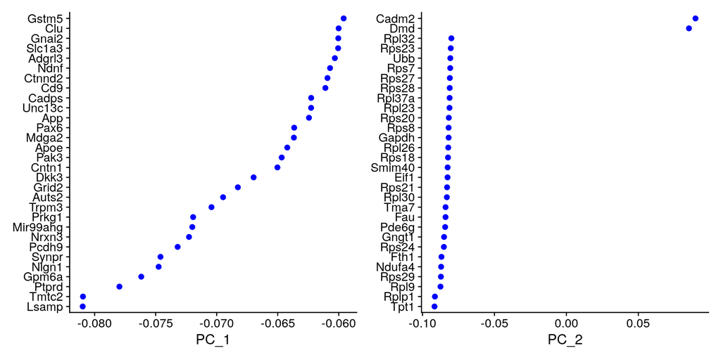

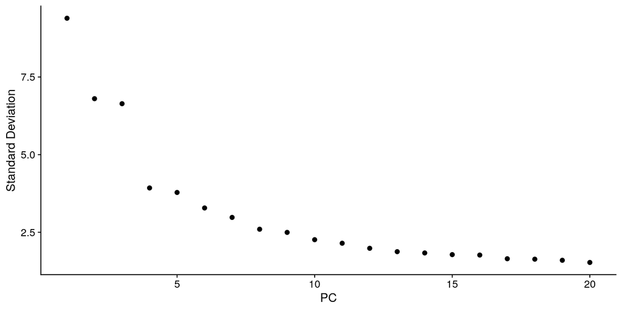

```
## Plot UMAP
## [1] "UMAPndim30nn30"
## [1] "/sc-rna-seq-snap-legacy-Victoria-Knockout-shareable/analyses/upstream-analysis/plots/04_Filter_object/UMAPndim30nn30/"
```

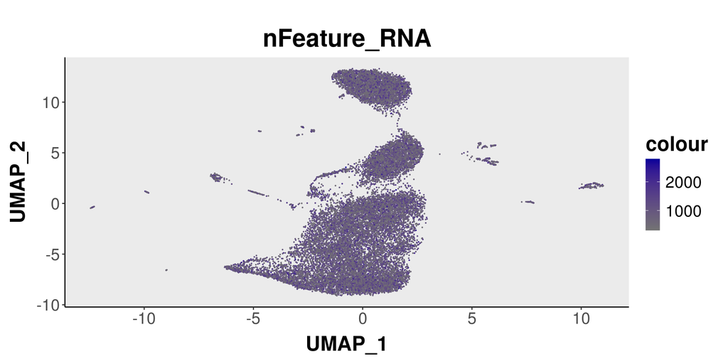

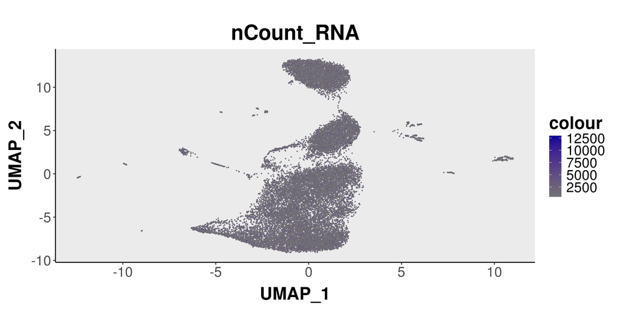

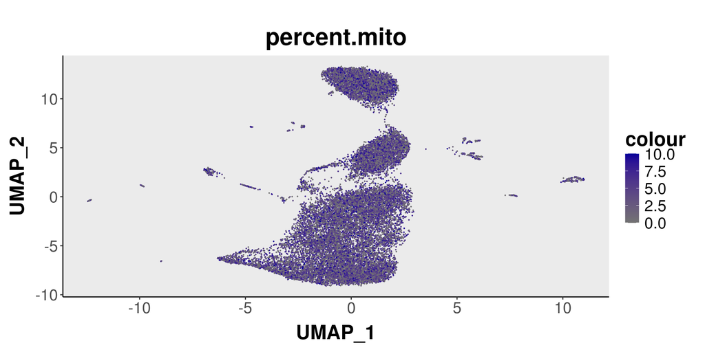

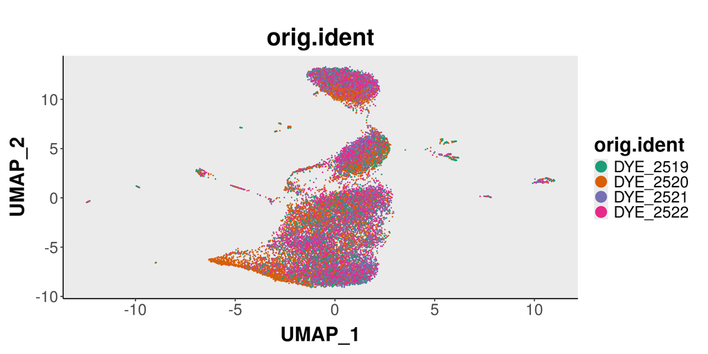

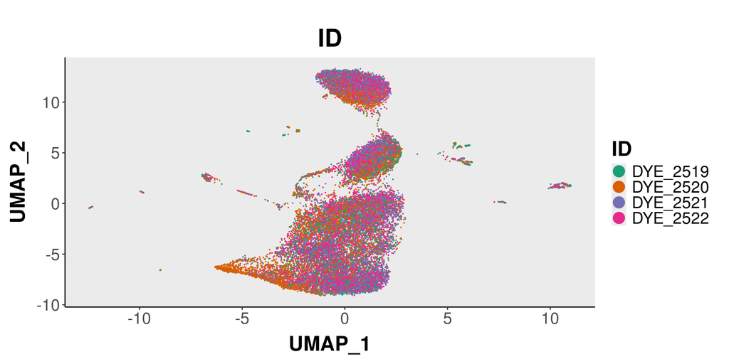

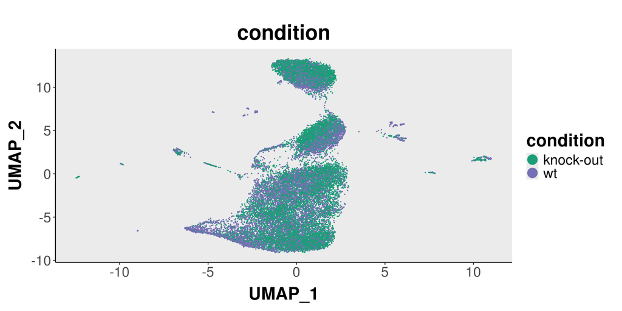

```
## [1] "Print condition_split!"
```

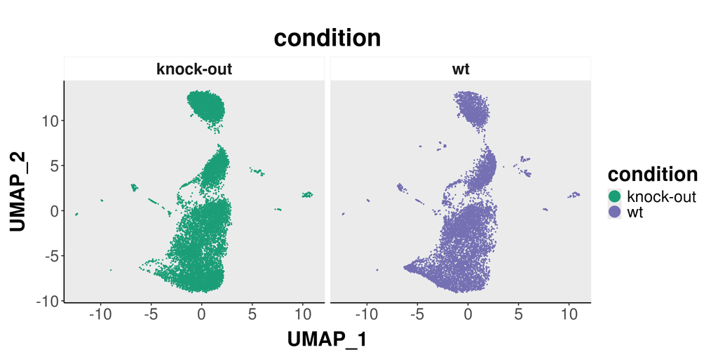

```
## Returned Seurat object
```

```r
seurat_obj <- Process_Seurat(seurat_obj = seurat_obj, nfeatures_value = nfeatures_value, Genome = genome_name,
                             Regress_Cell_Cycle = Regress_Cell_Cycle_value, assay = assay, num_pcs = num_pcs,
                             prefix = prefix, num_dim = num_dim, num_neighbors = num_neighbors, results_dir = results_dir,
                             plots_output = plots_dir, use_condition_split = use_condition_split,
                             condition1 = condition_value1, condition2 = condition_value2, condition3 = condition_value3,
                             print_pdf = print_pdf, PCA_Feature_List = PCA_Feature_List_value)
```

# 10 Save output files